# Decision trees

Created on JupyterLite

Libraries

```python
import piplite
await piplite.install(['pandas'])
await piplite.install(['matplotlib'])
await piplite.install(['numpy'])
await piplite.install(['scikit-learn'])
```

```python
import numpy as np
import pandas as pd
from sklearn.tree import DecisionTreeClassifier
import sklearn.tree as tree
```

```python
my_data = pd.read_csv("drug200.csv", delimiter=",")
my_data.head()
```

|  | Age | Sex | BP | Cholesterol | Na_to_K | Drug |
| --- | --- | --- | --- | --- | --- | --- |
| 0 | 23 | F | HIGH | HIGH | 25.355 | drugY |
| 1 | 47 | M | LOW | HIGH | 13.093 | drugC |
| 2 | 47 | M | LOW | HIGH | 10.114 | drugC |
| 3 | 28 | F | NORMAL | HIGH | 7.798 | drugX |
| 4 | 61 | F | LOW | HIGH | 18.043 | drugY |

```python
my_data.shape
```

```
(200, 6)
```

Feature matrix

```python
X = my_data[['Age', 'Sex', 'BP', 'Cholesterol', 'Na_to_K']].values
X[0:5]
```

```
array([[23, 'F', 'HIGH', 'HIGH', 25.355],
       [47, 'M', 'LOW', 'HIGH', 13.093],
       [47, 'M', 'LOW', 'HIGH', 10.114],
       [28, 'F', 'NORMAL', 'HIGH', 7.798],
       [61, 'F', 'LOW', 'HIGH', 18.043]], dtype=object)
```

```python
from sklearn import preprocessing
le_sex = preprocessing.LabelEncoder()
le_sex.fit(['F','M'])
X[:,1] = le_sex.transform(X[:,1])


le_BP = preprocessing.LabelEncoder()
le_BP.fit([ 'LOW', 'NORMAL', 'HIGH'])
X[:,2] = le_BP.transform(X[:,2])


le_Chol = preprocessing.LabelEncoder()
le_Chol.fit([ 'NORMAL', 'HIGH'])
X[:,3] = le_Chol.transform(X[:,3])

X[0:5]
```

```
array([[23, 0, 0, 0, 25.355],
       [47, 1, 1, 0, 13.093],
       [47, 1, 1, 0, 10.114],
       [28, 0, 2, 0, 7.798],
       [61, 0, 1, 0, 18.043]], dtype=object)
```

Response vector

```python
# Count of each class
my_data["Drug"].value_counts()
```

```
drugY    91
drugX    54
drugA    23
drugC    16
drugB    16
Name: Drug, dtype: int64
```

```python
y = my_data["Drug"]
y[0:5]
```

```
0    drugY
1    drugC
2    drugC
3    drugX
4    drugY
Name: Drug, dtype: object
```

Select random rows to set apart 70% of the data for training and 30% for testing

```python
from sklearn.model_selection import train_test_split
X_trainset, X_testset, y_trainset, y_testset = train_test_split(X, y, test_size=0.3, random_state=3)
```

```python
print('Shape of X training set {}'.format(X_trainset.shape),'&',' Size of Y training set {}'.format(y_trainset.shape))
print('Shape of X testing set {}'.format(X_testset.shape),'&',' Size of Y testing set {}'.format(y_testset.shape))
```

```
Shape of X training set (140, 5) &  Size of Y training set (140,)
Shape of X testing set (60, 5) &  Size of Y testing set (60,)
```

Decision tree classifier

"Criterion" is the function to measure the quality of a split. Supported criteria are “gini” for the Gini impurity and “log_loss” and “entropy” both for the Shannon information gain

"max_depth" is the maximum depth of the tree.

```python
drugTree = DecisionTreeClassifier(criterion="entropy", max_depth = 4)
drugTree # it shows the default parameters
```

```
DecisionTreeClassifier(criterion='entropy', max_depth=4)
```

Training

```python
drugTree.fit(X_trainset,y_trainset)
```

```
DecisionTreeClassifier(criterion='entropy', max_depth=4)
```

Prediction

```python
predTree = drugTree.predict(X_testset)
```

Visually compare the predictions to actual values

```python
print (predTree [0:5])
```

```
['drugY' 'drugX' 'drugX' 'drugX' 'drugX']
```

```python
print (y_testset [0:5])
```

```
40     drugY
51     drugX
139    drugX
197    drugX
170    drugX
Name: Drug, dtype: object
```

Metrics

```python
from sklearn import metrics
import matplotlib.pyplot as plt
print("DecisionTrees's Accuracy: ", metrics.accuracy_score(y_testset, predTree))
```

```
DecisionTrees's Accuracy:  0.9833333333333333
```

```python
metrics.confusion_matrix(y_testset, predTree, labels = ['drugY', 'drugX', 'drugA', 'drugB', 'drugC'])
```

```
array([[22,  0,  0,  0,  0],
       [ 1, 20,  0,  0,  0],
       [ 0,  0,  7,  0,  0],
       [ 0,  0,  0,  5,  0],
       [ 0,  0,  0,  0,  5]], dtype=int64)
```

```python
metrics.f1_score(y_testset, predTree, average = None, labels = ['drugY', 'drugX', 'drugA', 'drugB', 'drugC'])
```

```
array([0.97777778, 0.97560976, 1.        , 1.        , 1.        ])
```

```python
metrics.recall_score(y_testset, predTree, average=None, labels = ['drugY', 'drugX', 'drugA', 'drugB', 'drugC'])
```

```
array([1.        , 0.95238095, 1.        , 1.        , 1.        ])
```

```python
metrics.precision_score(y_testset, predTree, average=None, labels = ['drugY', 'drugX', 'drugA', 'drugB', 'drugC'])
```

```
array([0.95652174, 1.        , 1.        , 1.        , 1.        ])
```

Visualization of the decision tree

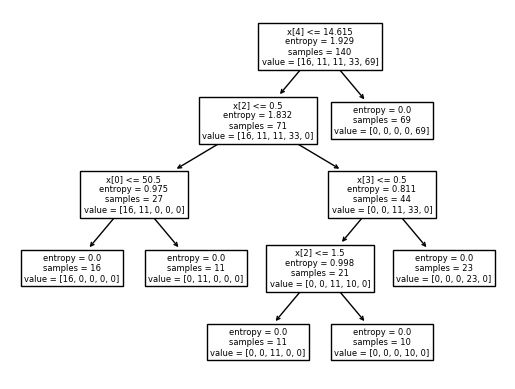

```python
tree.plot_tree(drugTree)
plt.show()
```

# Authors' rights

Machine Learning with Python course by IBM on Coursera: https://www.coursera.org/learn/machine-learning-with-python/

Completed and modified by Mathilde Marie Duville as part of the IBM Artificial Intelligence Engineering Professional Certificate and corresponding IBM badges. Please, follow the subsequent links to confirm the accreditation:

https://www.coursera.org/account/accomplishments/professional-cert/KSLW773DAATP?utm_source=link&utm_medium=certificate&utm_content=cert_image&utm_campaign=sharing_cta&utm_product=prof

https://www.credly.com/users/mathilde-marie-duville/badges

Author: Saeed Aghabozorgi

Other Contributors: Joseph Santarcangelo

Change Log

Date (YYYY-MM-DD) Version Changed By Change Description

2023-04-05 2.3 Anita Verma Changed pandas.get_dummies() to LabelEncoder

2020-11-20 2.2 Lakshmi Changed import statement of StringIO

2020-11-03 2.1 Lakshmi Changed URL of the csv

2020-08-27 2.0 Lavanya Moved lab to course repo in GitLab

© IBM Corporation 2020. All rights reserved.